# Zone Exit Value Above Expected

# Part 3: Evaluating Teams and Players on Zone Exit Value

```r
#fit2 <- randomForest(successful_exit ~ ., data=model_exits2, importance=TRUE, ntree=500, do.trace = 50)
#save(fit2, file = "Final Data Spring xExit Model.Rda")
load("Final Data Spring xExit Model.Rda")
me3 <- add_predictions(model_exits1, model = fit2, var = "xExit") %>%
  mutate(added_value = successful_exit - xExit)
```

We now have the xExit values from the model as the expected probability of a successful exit. We can compare actual values to this to see how much additional value over expected was created by the people involved. For example, we can evaluate this on a team level to see which teams are doing better at zone exits than we would expect with the available data. We’ll do this as an overall value added stat, a per game stat (to correct for teams having a different # of games played in the tracked sample), and a per exit stat (to correct for frequency of exits).

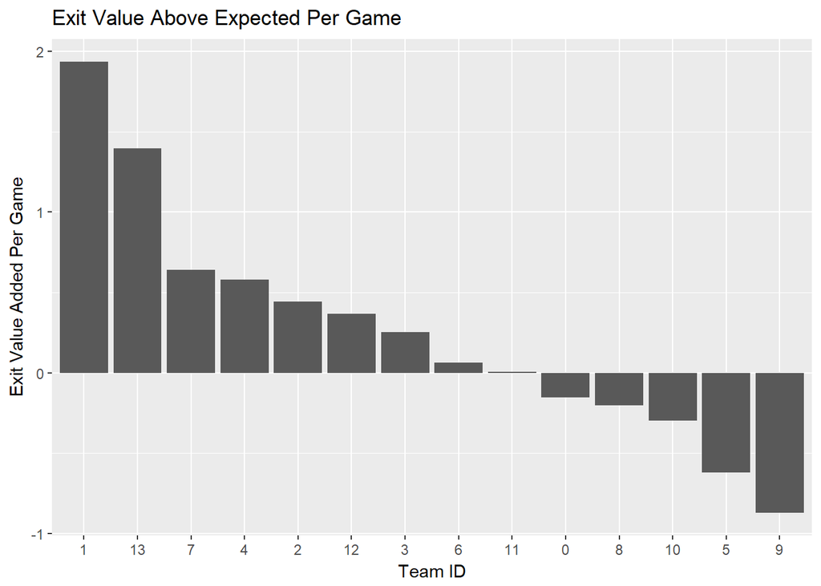

```r
team_value_for <- me3 %>%
  group_by(team_id) %>%
  summarise(exit_attempts = n(),
            exit_value_added = sum(added_value),
            gp = n_distinct(game_id)) %>%
  mutate(extra_value_pergame = exit_value_added / gp,
         extra_value_perexit = exit_value_added / exit_attempts,
         team_id = as.factor(team_id))
ggplot(team_value_for, aes(x = reorder(team_id, -extra_value_pergame), y = extra_value_pergame)) + geom_col() +
  labs(x = "Team ID", y = "Exit Value Added Per Game",
       title = "Exit Value Above Expected Per Game")
```

I’d be very curious to see how these number line up against qualitiative evaluation of these teams’ ability to exit the neutral zone. My hope is that this accurately reflects a measure of how well each team transitions play across the rink. One limitation is that some teams may do better here because they succeed despite putting themselves in bad exit positions (or vice versa), but that would require additional research and knowledge to incorporate.

We can also conduct this analysis on each team’s opponents to see the defensive equivalent: essentially, which teams make their opponents do worse at zone exits than expected.

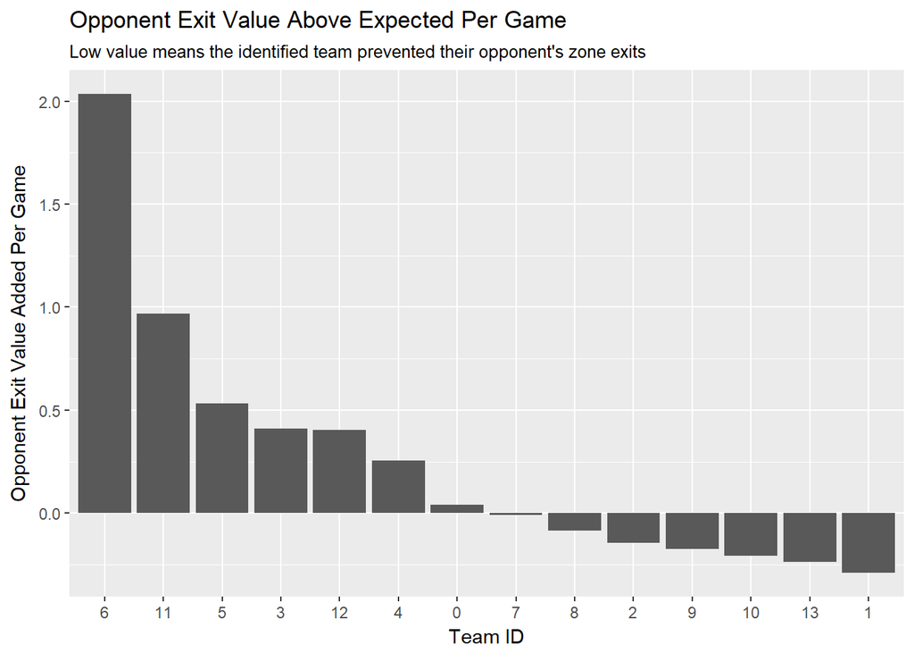

```r
team_value_against <- me3 %>%
  mutate(opp = ifelse(team_id == home_team, away_team, home_team)) %>%
  group_by(opp) %>%
  summarise(exit_attempts = n(),
            exit_value_added = sum(added_value),
            gp = n_distinct(game_id)) %>%
  mutate(extra_value_pergame = exit_value_added / gp,
         extra_value_perexit = exit_value_added / exit_attempts,
         opp = as.factor(opp))
ggplot(team_value_against, aes(x = reorder(opp, -extra_value_pergame), y = extra_value_pergame)) + geom_col() +
  labs(x = "Team ID", y = "Opponent Exit Value Added Per Game",
       title = "Opponent Exit Value Above Expected Per Game",
       subtitle = "Low value means the identified team prevented their opponent's zone exits")
```

Based on this, I would predice that teams 1, 7, and 13 are some of the stronger teams in the AHL, at least when it comes to transitional play. Team 9 bogs things down and has fewer zone exits in both directions. Team 11 allows a lot and generates transitions at a below average rate.

Similarly, we can repeat this process for each player. For now, we’ll focus only on the exits where the player in question is responsible for the exit. In the future, it would be interesting to see the results for any exit in which that player is on-ice, as it’s possible their pass reception, positioning or another factor could help the team exit even without their direct involvement in the defensive zone. We could also find the off-ice version to calculate Rel stats. But for now, we’ll accept this version and pause to see how well it is doing.

```r
player_value_for <- me3 %>%
  group_by(team_id, main_player_id) %>%
  summarise(exit_attempts = n(),
            exit_value_added = sum(added_value),
            gp = n_distinct(game_id)) %>%
  mutate(extra_value_pergame = exit_value_added / gp,
         extra_value_perexit = exit_value_added / exit_attempts) %>%
  arrange(desc(extra_value_pergame))
head(player_value_for) #Best players
```

```
## # A tibble: 6 x 7
## # Groups:   team_id [4]
##   team_id main_player_id exit_attempts exit_value_added    gp
##     <int>          <int>         <int>            <dbl> <int>
## 1       5            328             5        1.2206800     1
## 2       5            321            25        1.6669961     2
## 3       0            215             3        0.8146100     1
## 4       1            396             4        0.7768921     1
## 5       3            308            40        6.6118615     9
## 6       1            395            23        2.0856311     3
## # ... with 2 more variables: extra_value_pergame <dbl>,
## #   extra_value_perexit <dbl>
```

```r
tail(player_value_for) #Worst players
```

```
## # A tibble: 6 x 7
## # Groups:   team_id [6]
##   team_id main_player_id exit_attempts exit_value_added    gp
##     <int>          <int>         <int>            <dbl> <int>
## 1       0            220            39       -5.5897158     8
## 2       2            108             1       -0.7001210     1
## 3       6            465             3       -0.7159072     1
## 4      13             53             9       -1.8741971     2
## 5      11            363             4       -0.9497968     1
## 6       7            433            37       -4.0102577     4
## # ... with 2 more variables: extra_value_pergame <dbl>,
## #   extra_value_perexit <dbl>
```